# Coralline bacteria

Shaun Nielsen

Wednesday, April 29, 2015

This tutorial runs you through some features of the MVAbund package:

http://cran.r-project.org/web/packages/mvabund/

#### Loading data

Coralline.bacteria.RData is a data list that has two dataframes including:

1. Counts of bacterial classes on two species of coralline algae -“bac.class”
2. Sample information - “bac.treat”

Load the list and extract the two data frames.

```r
setwd("/Users/vamshidhar/Documents/OneDrive/github/ZiggyWorkshop")
load("Corallina.bacteria.RData")
bac.class=coralline.bac$bac.class
bac.treat=coralline.bac$bac.treat
```

#### Installing MVAbund

```r
install.packages('mvabund') # Run once only to download to the computer
```

```r
library('mvabund') # Load the package
```

#### Using MVabund

First make an MVabund object from your count data frame.

```r
dat.mv=mvabund(bac.class)
```

Mvabund has some plotting functions. It does the job but it very raw. There are other ways to do get better looking figures, but at this stage we just want to see the data.

```
## Overlapping points were shifted along the y-axis to make them visible.
```

```
##
##  PIPING TO 2nd MVFACTOR
```

```
## Only the variables Proteobacteria.Gammaproteobacteria, Bacteroidetes.Flavobacteria, Proteobacteria.Alphaproteobacteria, Actinobacteria.Actinobacteria, Bacteroidetes.Sphingobacteria, Cyanobacteria.Synechococcophycideae, unclassified.unclassified, Bacteroidetes.unclassified, Cyanobacteria.Oscillato…
## (the variables with highest total abundance).
```

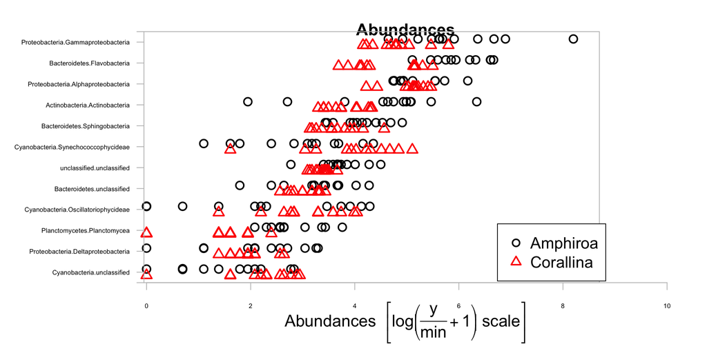

```r
plot(dat.mv~bac.treat$Species,cex.axis=0.55) # Raw data plot
```

```
## Overlapping points were shifted along the y-axis to make them visible.
```

```
##
##  PIPING TO 2nd MVFACTOR
```

```
## Only the variables Proteobacteria.Gammaproteobacteria, Bacteroidetes.Flavobacteria, Proteobacteria.Alphaproteobacteria, Actinobacteria.Actinobacteria, Bacteroidetes.Sphingobacteria, Cyanobacteria.Synechococcophycideae, unclassified.unclassified, Bacteroidetes.unclassified, Cyanobacteria.Oscillato…
## (the variables with highest total abundance).
```

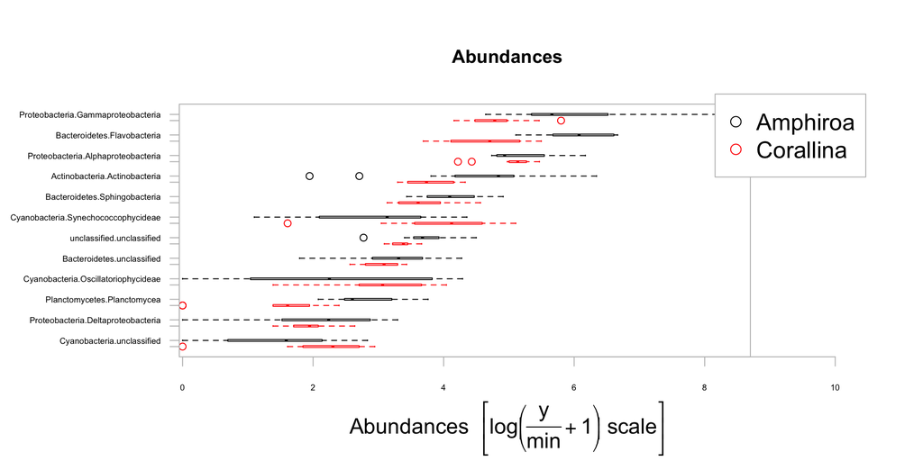

```r
plot(dat.mv~bac.treat$Species,type="bx",cex.axis=0.55) # Box plot
```

can add transformation=“none”

We will check the mean variance relationship which will dictate what kind of model to use.

```
## START SECTION 2
## Plotting if overlay is TRUE
```

```
## using grouping variable bac.treat$Species 18 mean values were 0 and could
##                                      not be included in the log-plot
## using grouping variable bac.treat$Species 18 variance values were 0 and could not
##                                      be included in the log-plot
```

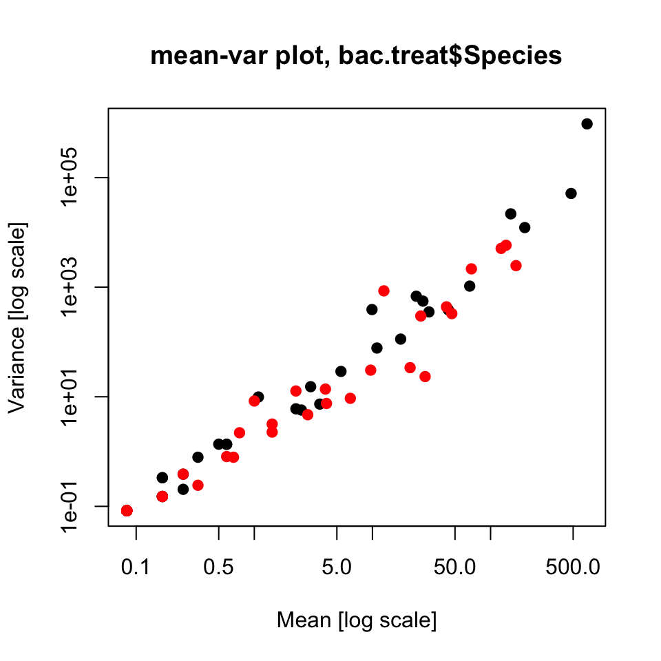

```
## FINISHED SECTION 2
```

```r
meanvar.plot(dat.mv~bac.treat$Species,pch=19)
```

The variance increases with the mean hinting at data that comes from a negative binomial distribution.

```r
# Use the data=bac.treat here to remove unnecessary characters in the output
dat.nb=manyglm(dat.mv~Species, family="negative.binomial", data=bac.treat)
```

To check how well the model fits the data a residual plot is used. It has been suggested to make a few of these since a randomisation procedure is used in MVabund.

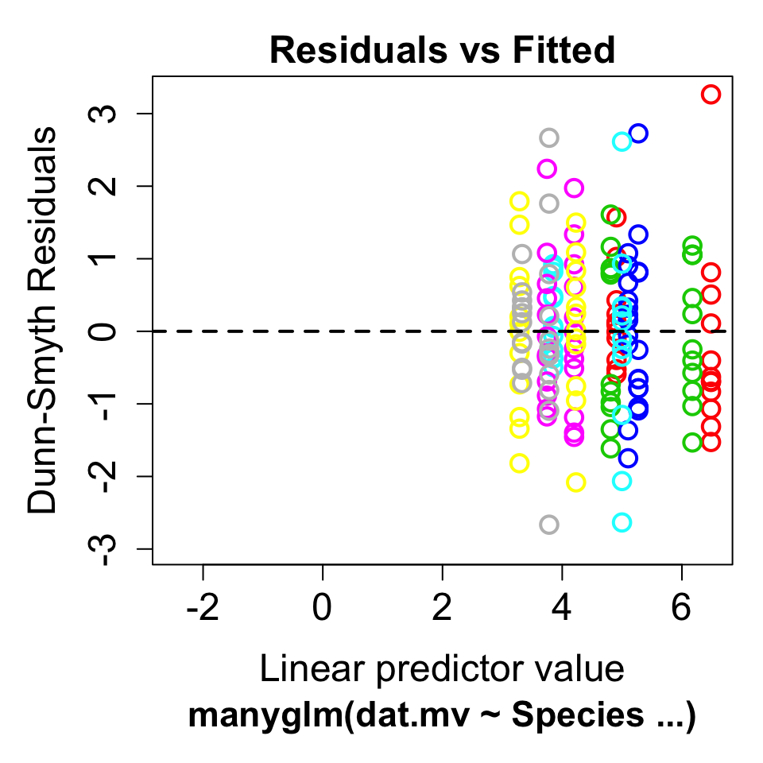

```r
plot(dat.nb,n.vars=15) # involves some randomisation, repeat it a couple of times
```

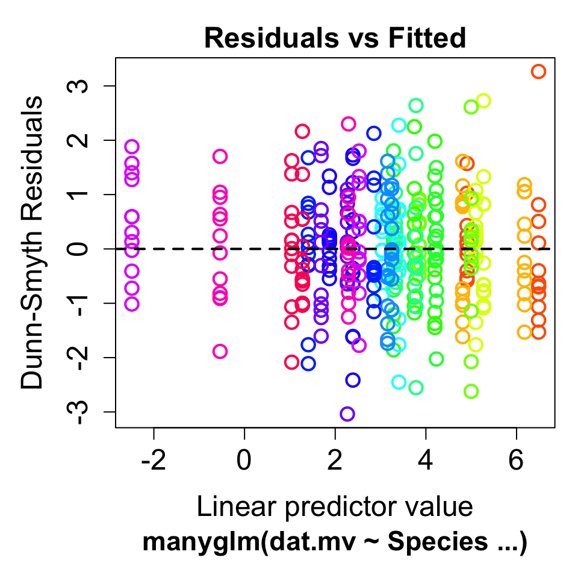

```r
plot(dat.nb,n.vars=15)
```

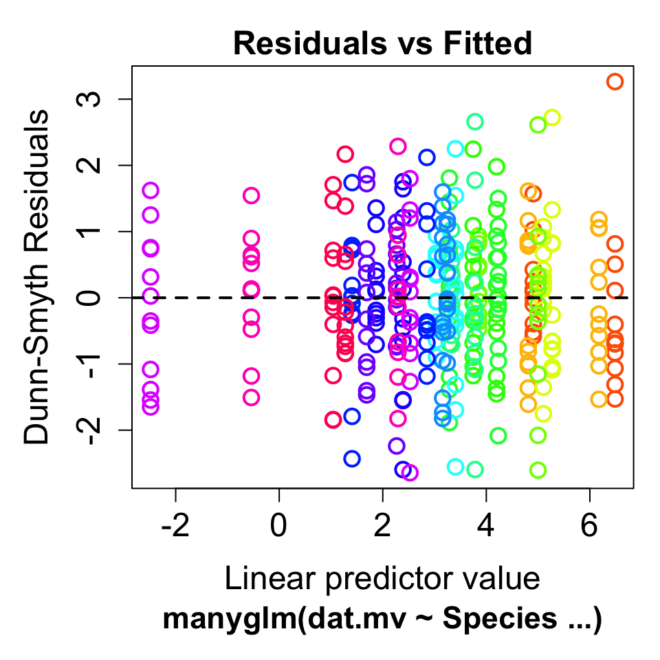

```r
plot(dat.nb,n.vars=15)
```

No obvious pattern among multiple plots - a good model fit.

An ANOVA is then carried out.

```r
dat.aov=anova(dat.nb,nBoot=100,p.uni="adjusted") # used nBoot = 100 for trial, 999 for publication
```

```
## Time elapsed: 0 hr 0 min 1 sec
```

```r
dat.aov$table # multivariate table
```

```
##             Res.Df Df.diff      Dev Pr(>Dev)
## (Intercept)     23      NA       NA       NA
## Species         22       1 162.8367     0.01
```

We can see the is a difference in the multivariate test statistic. We would then ask which variables constituted to this effect.

We can look at test statistics and p values here. Note that the output is quite horrible here given the long variable names. A good idea is to plot any one of these to see how they behave.

```r
dat.aov$uni.test # univariate test statistics
```

```
##             Acidobacteria.Acidobacteria Acidobacteria.Chloracidobacteria
## (Intercept)                          NA                               NA
## Species                        3.896977                         0.531649
##             Acidobacteria.RB25 Acidobacteria.Sva0725
## (Intercept)                 NA                    NA
## Species                1.38627            0.04470626
##             Actinobacteria.Actinobacteria Bacteroidetes.unclassified
## (Intercept)                            NA                         NA
## Species                          11.61902                   3.201768
##             Bacteroidetes.Sphingobacteria Bacteroidetes.Bacteroidia
## (Intercept)                            NA                        NA
## Species                          5.562835                  2.772565
##             Bacteroidetes.Flavobacteria Chloroflexi.Anaerolineae
## (Intercept)                          NA                       NA
## Species                        23.20757                 2.005149
##             Chloroflexi.Dehalococcoidetes Chloroflexi.SOGA31
## (Intercept)                            NA                 NA
## Species                           1.38627            1.38627
##             Cyanobacteria.unclassified Cyanobacteria.4C0d.2
## (Intercept)                         NA                   NA
## Species                        2.73914              1.38627
##             Cyanobacteria.Nostocophycideae
## (Intercept)                             NA
## Species                           2.772565
##             Cyanobacteria.Oscillatoriophycideae
## (Intercept)                                  NA
## Species                              0.04029714
##             Cyanobacteria.Synechococcophycideae Firmicutes.Bacilli
## (Intercept)                                  NA                 NA
## Species                                6.750967          0.1433471
##             Firmicutes.Clostridia Firmicutes.unclassified
## (Intercept)                    NA                      NA
## Species                  3.018432                 1.38627
##             Fusobacteria.Fusobacteria Gemmatimonadetes.Gemmatimonadetes
## (Intercept)                        NA                                NA
## Species                      2.093191                           1.38627
##             GN02.BB34 GN02.GKS2.174 GN02.VC12.cl04
## (Intercept)        NA            NA             NA
## Species             0             0       4.564562
##             Lentisphaerae.Lentisphaerae OP3.koll11 Planctomycetes.agg27
```

[output cut: 19 more lines]

```
## Species                                0.1269305          1.457325
##             Spirochaetes.Spirochaetes Synergistetes.Synergistia
## (Intercept)                        NA                        NA
## Species                       1.38627                 0.3397981
##             TM7.unclassified unclassified.unclassified
## (Intercept)               NA                        NA
## Species             2.772565                  9.397283
##             Verrucomicrobia.Opitutae Verrucomicrobia.Verrucomicrobiae
## (Intercept)                       NA                               NA
## Species                    0.7477686                       0.05838252
##             ZB2.unclassified
## (Intercept)               NA
## Species             1.457325
## attr(,"title")
## [1] "Univariate Tests:"
```

```r
dat.aov$uni.p # univariate adjusted p values, note we are interested in row 2
```

```
##             Acidobacteria.Acidobacteria Acidobacteria.Chloracidobacteria
## (Intercept)                          NA                               NA
## Species                            0.75                                1
##             Acidobacteria.RB25 Acidobacteria.Sva0725
## (Intercept)                 NA                    NA
## Species                      1                     1
##             Actinobacteria.Actinobacteria Bacteroidetes.unclassified
## (Intercept)                            NA                         NA
## Species                              0.04                       0.82
##             Bacteroidetes.Sphingobacteria Bacteroidetes.Bacteroidia
## (Intercept)                            NA                        NA
## Species                               0.3                      0.96
##             Bacteroidetes.Flavobacteria Chloroflexi.Anaerolineae
## (Intercept)                          NA                       NA
## Species                            0.01                     0.97
##             Chloroflexi.Dehalococcoidetes Chloroflexi.SOGA31
## (Intercept)                            NA                 NA
## Species                                 1                  1
##             Cyanobacteria.unclassified Cyanobacteria.4C0d.2
## (Intercept)                         NA                   NA
## Species                           0.96                    1
##             Cyanobacteria.Nostocophycideae
## (Intercept)                             NA
## Species                               0.92
##             Cyanobacteria.Oscillatoriophycideae
## (Intercept)                                  NA
## Species                                       1
##             Cyanobacteria.Synechococcophycideae Firmicutes.Bacilli
## (Intercept)                                  NA                 NA
## Species                                    0.22                  1
##             Firmicutes.Clostridia Firmicutes.unclassified
## (Intercept)                    NA                      NA
## Species                      0.85                       1
##             Fusobacteria.Fusobacteria Gemmatimonadetes.Gemmatimonadetes
## (Intercept)                        NA                                NA
## Species                          0.97                                 1
##             GN02.BB34 GN02.GKS2.174 GN02.VC12.cl04
## (Intercept)        NA            NA             NA
## Species             1             1           0.58
##             Lentisphaerae.Lentisphaerae OP3.koll11 Planctomycetes.agg27
```

[output cut: 19 more lines]

```
## Species                                        1              0.99
##             Spirochaetes.Spirochaetes Synergistetes.Synergistia
## (Intercept)                        NA                        NA
## Species                             1                         1
##             TM7.unclassified unclassified.unclassified
## (Intercept)               NA                        NA
## Species                 0.96                      0.07
##             Verrucomicrobia.Opitutae Verrucomicrobia.Verrucomicrobiae
## (Intercept)                       NA                               NA
## Species                            1                                1
##             ZB2.unclassified
## (Intercept)               NA
## Species                 0.99
## attr(,"title")
## [1] "Univariate Tests:"
```

```r
any(dat.aov$uni.p[2,]<0.05) # so some bacterial classes differed between species
```

```
## [1] TRUE
```

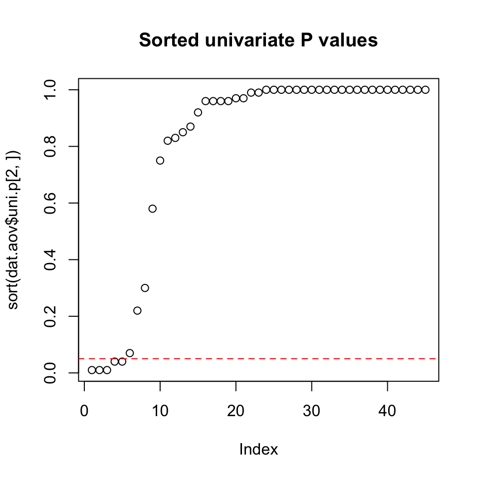

```r
plot(sort(dat.aov$uni.p[2,]), main="Sorted univariate P values")

abline(h=0.05, lty=2, col="red")
```

Around 5-6 classes around p = 0.05. Who are these?

```r
diffs=which(dat.aov$uni.p[2,]<0.1) # ask for < 0.1 so we catch the group slightly above 0.05

diffs
```

```
##      Actinobacteria.Actinobacteria        Bacteroidetes.Flavobacteria
##                                  5                                  9
##        Planctomycetes.Planctomycea Proteobacteria.Gammaproteobacteria
##                                 30                                 32
##  Proteobacteria.Betaproteobacteria          unclassified.unclassified
##                                 35                                 42
```

numbers here are column numbers in data.frame

What proportion did these groups have on the multivariate test statistic?

```r
sum(dat.aov$uni.test[2,diffs])/sum(dat.aov$uni.test[2,])*100
```

```
## [1] 56.4946
```

About 56 %. We can then plot the abundances of only these groups.

```
## Overlapping points were shifted along the y-axis to make them visible.
```

```
##
##  PIPING TO 2nd MVFACTOR
```

```
## Only the variables Actinobacteria.Actinobacteria, Bacteroidetes.Flavobacteria, Planctomycetes.Planctomycea, Proteobacteria.Gammaproteobacteria, Proteobacteria.Betaproteobacteria, unclassified.unclassified were included in the plot (user selected).
```

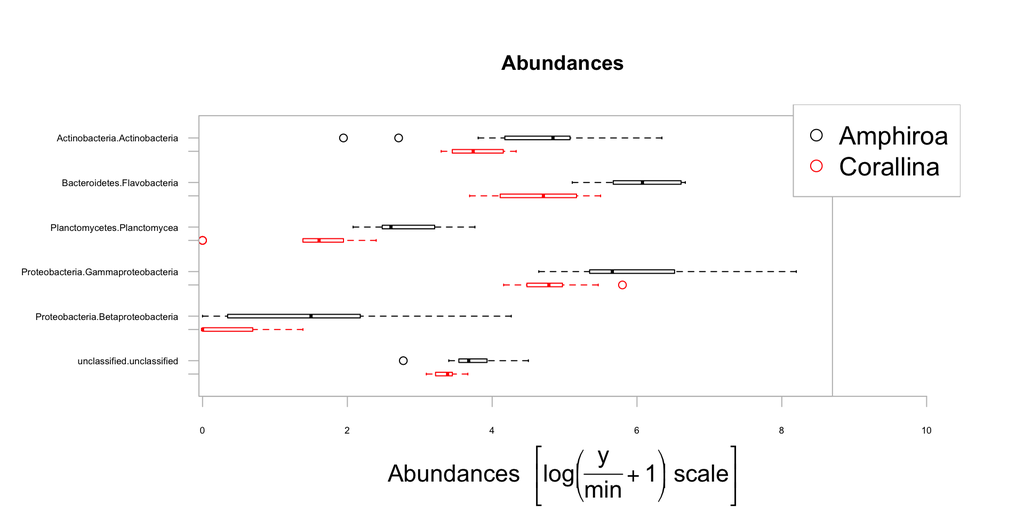

```r
palette('default') # Mvabund screws your colour palette up, so reset

plot(dat.mv~bac.treat$Species, var.subset=diffs,
     type="bx",cex.axis=0.55)
```

Mvabund gives model summaries too, note it calculates p values by bootstrapping so keep this in mind for timing.

```r
dat.nb.sum=summary(dat.nb, nBoot=100,p.uni="adjusted")

dat.nb.sum
```

```
##
## Test statistics:
##                  wald value Pr(>wald)
## (Intercept)           97.22      0.01 **
## SpeciesCorallina      13.41      0.01 **
## ---
## Signif. codes:  0 '***' 0.001 '**' 0.01 '*' 0.05 '.' 0.1 ' ' 1
##
## Univariate test statistic:
##                                      (Intercept)
##                                       wald value Pr(>wald)
## Acidobacteria.Acidobacteria                1.654      0.59
## Acidobacteria.Chloracidobacteria           1.029      0.83
## Acidobacteria.RB25                         0.051      0.91
## Acidobacteria.Sva0725                      1.181      0.83
## Actinobacteria.Actinobacteria             24.088      0.01
## Bacteroidetes.unclassified                24.640      0.01
## Bacteroidetes.Sphingobacteria             33.152      0.01
## Bacteroidetes.Bacteroidia                  2.534      0.34
## Bacteroidetes.Flavobacteria               40.487      0.01
## Chloroflexi.Anaerolineae                   2.749      0.29
## Chloroflexi.Dehalococcoidetes              2.485      0.34
## Chloroflexi.SOGA31                         0.051      0.91
## Cyanobacteria.unclassified                 6.879      0.01
## Cyanobacteria.4C0d.2                       0.051      0.91
## Cyanobacteria.Nostocophycideae             0.051      0.91
## Cyanobacteria.Oscillatoriophycideae       10.160      0.01
## Cyanobacteria.Synechococcophycideae       13.712      0.01
## Firmicutes.Bacilli                         2.401      0.34
## Firmicutes.Clostridia                      1.829      0.45
## Firmicutes.unclassified                    0.051      0.91
## Fusobacteria.Fusobacteria                  1.138      0.83
## Gemmatimonadetes.Gemmatimonadetes          0.051      0.91
## GN02.BB34                                  2.485      0.34
## GN02.GKS2.174                              2.485      0.34
## GN02.VC12.cl04                             1.012      0.83
## Lentisphaerae.Lentisphaerae                2.485      0.34
## OP3.koll11                                 0.051      0.91
## Planctomycetes.agg27                       3.529      0.09
## Planctomycetes.Phycisphaerae               0.051      0.91
```

[output cut: 129 more lines]

```
##            Spirochaetes.Spirochaetes Synergistetes.Synergistia
## wald value                     0.043                     0.566
## Pr(>wald)                       1.00                      0.98
##            TM7.unclassified unclassified.unclassified
## wald value            0.045                     3.368
## Pr(>wald)              1.00                      0.04
##            Verrucomicrobia.Opitutae Verrucomicrobia.Verrucomicrobiae
## wald value                    0.844                            0.242
## Pr(>wald)                      0.96                             1.00
##            ZB2.unclassified
## wald value            0.045
## Pr(>wald)              1.00
## Arguments:
##  Test statistics calculated assuming response assumed to be uncorrelated
##  P-value calculated using 99 resampling iterations via pit.trap resampling (to account for correlation in testing).
```

```r
dat.nb.sum$est # estimates/coefficents
```

```
##                  Gen. Var Acidobacteria.Acidobacteria
## (Intercept)             0                   -2.484907
## SpeciesCorallina        0                    5.010635
##                  Acidobacteria.Chloracidobacteria Acidobacteria.RB25
## (Intercept)                             -1.098612          -14.81551
## SpeciesCorallina                         1.098612           12.33060
##                  Acidobacteria.Sva0725 Actinobacteria.Actinobacteria
## (Intercept)                 -0.5389965                      4.998900
## SpeciesCorallina             0.1335314                     -1.148752
##                  Bacteroidetes.unclassified Bacteroidetes.Sphingobacteria
## (Intercept)                        3.403971                     4.1984543
## SpeciesCorallina                  -0.367417                    -0.4528795
##                  Bacteroidetes.Bacteroidia Bacteroidetes.Flavobacteria
## (Intercept)                      -1.791759                    6.174827
## SpeciesCorallina                -13.023751                   -1.363999
##                  Chloroflexi.Anaerolineae Chloroflexi.Dehalococcoidetes
## (Intercept)                     0.8109302                     -2.484907
## SpeciesCorallina                0.5753641                    -12.330604
##                  Chloroflexi.SOGA31 Cyanobacteria.unclassified
## (Intercept)               -14.81551                  1.6894806
## SpeciesCorallina           12.33060                  0.5792029
##                  Cyanobacteria.4C0d.2 Cyanobacteria.Nostocophycideae
## (Intercept)                 -14.81551                      -14.81551
## SpeciesCorallina             12.33060                       13.02375
##                  Cyanobacteria.Oscillatoriophycideae
## (Intercept)                               3.15700042
## SpeciesCorallina                          0.08819271
##                  Cyanobacteria.Synechococcophycideae Firmicutes.Bacilli
## (Intercept)                                3.2865345         -1.3862944
## SpeciesCorallina                           0.9451537          0.2876821
##                  Firmicutes.Clostridia Firmicutes.unclassified
## (Intercept)                  -1.386294               -14.81551
## SpeciesCorallina            -13.429216                12.33060
##                  Fusobacteria.Fusobacteria
## (Intercept)                     -0.5389965
## SpeciesCorallina                 0.8873032
##                  Gemmatimonadetes.Gemmatimonadetes     GN02.BB34
## (Intercept)                              -14.81551 -2.484907e+00
## SpeciesCorallina                          12.33060 -8.881784e-16
##                  GN02.GKS2.174 GN02.VC12.cl04 Lentisphaerae.Lentisphaerae
```

[output cut: 26 more lines]

```
##                  Proteobacteria.Epsilonproteobacteria SBR1093.VHS.B5.50
## (Intercept)                                0.08004271         -1.791759
## SpeciesCorallina                          -0.36772478        -13.023751
##                  Spirochaetes.Spirochaetes Synergistetes.Synergistia
## (Intercept)                      -2.484907                -1.7917595
## SpeciesCorallina                -12.330604                -0.6931472
##                  TM7.unclassified unclassified.unclassified
## (Intercept)             -1.791759                  3.782294
## SpeciesCorallina       -13.023751                 -0.453070
##                  Verrucomicrobia.Opitutae Verrucomicrobia.Verrucomicrobiae
## (Intercept)                     -2.484907                        0.9162907
## SpeciesCorallina                 1.098612                       -0.1053605
##                  ZB2.unclassified
## (Intercept)             -1.791759
## SpeciesCorallina       -13.023751
```

```r
dat.nb.sum$est.stderr # SE of estimates
```

```
##                  Acidobacteria.Acidobacteria
## (Intercept)                         1.502210
## SpeciesCorallina                    1.876149
##                  Acidobacteria.Chloracidobacteria Acidobacteria.RB25
## (Intercept)                              1.067369           288.6751
## SpeciesCorallina                         1.453233           288.6769
##                  Acidobacteria.Sva0725 Actinobacteria.Actinobacteria
## (Intercept)                  0.4564189                     0.2075225
## SpeciesCorallina             0.6314898                     0.2955370
##                  Bacteroidetes.unclassified Bacteroidetes.Sphingobacteria
## (Intercept)                       0.1381492                     0.1266421
## SpeciesCorallina                  0.1984951                     0.1810894
##                  Bacteroidetes.Bacteroidia Bacteroidetes.Flavobacteria
## (Intercept)                      0.7071068                   0.1525124
## SpeciesCorallina               288.6760006                   0.2168527
##                  Chloroflexi.Anaerolineae Chloroflexi.Dehalococcoidetes
## (Intercept)                     0.2950052                        1.0000
## SpeciesCorallina                0.3973065                      288.6769
##                  Chloroflexi.SOGA31 Cyanobacteria.unclassified
## (Intercept)                288.6751                  0.2456072
## SpeciesCorallina           288.6769                  0.3374639
##                  Cyanobacteria.4C0d.2 Cyanobacteria.Nostocophycideae
## (Intercept)                  288.6751                       288.6751
## SpeciesCorallina             288.6769                       288.6760
##                  Cyanobacteria.Oscillatoriophycideae
## (Intercept)                                0.3107289
## SpeciesCorallina                           0.4390963
##                  Cyanobacteria.Synechococcophycideae Firmicutes.Bacilli
## (Intercept)                                0.2396759          0.5773503
## SpeciesCorallina                           0.3361316          0.7637626
##                  Firmicutes.Clostridia Firmicutes.unclassified
## (Intercept)                  0.7581571                288.6751
## SpeciesCorallina           288.6761302                288.6769
##                  Fusobacteria.Fusobacteria
## (Intercept)                      0.4736349
## SpeciesCorallina                 0.6038431
##                  Gemmatimonadetes.Gemmatimonadetes GN02.BB34 GN02.GKS2.174
## (Intercept)                               288.6751  1.000000      1.000000
## SpeciesCorallina                          288.6769  1.414214      1.414214
##                  GN02.VC12.cl04 Lentisphaerae.Lentisphaerae OP3.koll11
```

[output cut: 23 more lines]

```
##                  Proteobacteria.Epsilonproteobacteria SBR1093.VHS.B5.50
## (Intercept)                                 0.7147105          1.249661
## SpeciesCorallina                            1.0275263        288.677839
##                  Spirochaetes.Spirochaetes Synergistetes.Synergistia
## (Intercept)                         1.0000                 0.7071068
## SpeciesCorallina                  288.6769                 1.2247449
##                  TM7.unclassified unclassified.unclassified
## (Intercept)             0.7071068                0.09221581
## SpeciesCorallina      288.6760006                0.13451785
##                  Verrucomicrobia.Opitutae Verrucomicrobia.Verrucomicrobiae
## (Intercept)                       1.08678                        0.3051344
## SpeciesCorallina                  1.30212                        0.4357956
##                  ZB2.unclassified
## (Intercept)              1.249661
## SpeciesCorallina       288.677839
```

```r
dat.nb.sum$uni.p # p values
```

```
##                                      (Intercept) SpeciesCorallina
## Acidobacteria.Acidobacteria                 0.59             0.24
## Acidobacteria.Chloracidobacteria            0.83             0.96
## Acidobacteria.RB25                          0.91             1.00
## Acidobacteria.Sva0725                       0.83             1.00
## Actinobacteria.Actinobacteria               0.01             0.02
## Bacteroidetes.unclassified                  0.01             0.60
## Bacteroidetes.Sphingobacteria               0.01             0.30
## Bacteroidetes.Bacteroidia                   0.34             1.00
## Bacteroidetes.Flavobacteria                 0.01             0.01
## Chloroflexi.Anaerolineae                    0.29             0.81
## Chloroflexi.Dehalococcoidetes               0.34             1.00
## Chloroflexi.SOGA31                          0.91             1.00
## Cyanobacteria.unclassified                  0.01             0.67
## Cyanobacteria.4C0d.2                        0.91             1.00
## Cyanobacteria.Nostocophycideae              0.91             1.00
## Cyanobacteria.Oscillatoriophycideae         0.01             1.00
## Cyanobacteria.Synechococcophycideae         0.01             0.14
## Firmicutes.Bacilli                          0.34             1.00
## Firmicutes.Clostridia                       0.45             1.00
## Firmicutes.unclassified                     0.91             1.00
## Fusobacteria.Fusobacteria                   0.83             0.81
## Gemmatimonadetes.Gemmatimonadetes           0.91             1.00
## GN02.BB34                                   0.34             1.00
## GN02.GKS2.174                               0.34             1.00
## GN02.VC12.cl04                              0.83             1.00
## Lentisphaerae.Lentisphaerae                 0.34             1.00
## OP3.koll11                                  0.91             1.00
## Planctomycetes.agg27                        0.09             0.75
## Planctomycetes.Phycisphaerae                0.91             1.00
## Planctomycetes.Planctomycea                 0.01             0.01
## Planctomycetes.vadinHA49                    0.91             1.00
## Proteobacteria.Gammaproteobacteria          0.01             0.01
## Proteobacteria.unclassified                 0.01             0.96
## Proteobacteria.Alphaproteobacteria          0.01             0.95
## Proteobacteria.Betaproteobacteria           0.01             0.02
## Proteobacteria.Deltaproteobacteria          0.01             0.61
## Proteobacteria.Epsilonproteobacteria        0.91             1.00
## SBR1093.VHS.B5.50                           0.73             1.00
## Spirochaetes.Spirochaetes                   0.34             1.00
## Synergistetes.Synergistia                   0.34             0.98
## TM7.unclassified                            0.34             1.00
## unclassified.unclassified                   0.01             0.04
## Verrucomicrobia.Opitutae                    0.34             0.96
## Verrucomicrobia.Verrucomicrobiae            0.13             1.00
## ZB2.unclassified                            0.73             1.00
```